# **Sequential NLP Project Solution**

## **PART A**

• DOMAIN: Digital content and entertainment industry

• CONTEXT: The objective of this project is to build a text classification model that analyses the customer's sentiments based on their reviews in the IMDB database. The model uses a complex deep learning model to build an embedding layer followed by a classification algorithm to analyse the sentiment of the customers.

• DATA DESCRIPTION: The Dataset of 50,000 movie reviews from IMDB, labelled by sentiment (positive/negative). Reviews have been preprocessed, and each review is encoded as a sequence of word indexes (integers). For convenience, the words are indexed by their frequency in the dataset, meaning the for that has index 1 is the most frequent word. Use the first 20 words from each review to speed up training, using a max vocabulary size of 10,000. As a convention, "0" does not stand for a specific word, but instead is used to encode any unknown word.

• PROJECT OBJECTIVE: To Build a sequential NLP classifier which can use input text parameters to determine the customer sentiments.

```python
# Imports
import numpy as np
import pandas as pd
import seaborn as sns
import keras
from keras.datasets import imdb
from sklearn.metrics import classification_report,  confusion_matrix
from keras.models import Sequential
from keras.layers import Embedding, Dense, Dropout, Flatten, Activation,  LSTM, MaxPooling1D, Conv1D,SimpleRNN
from keras.callbacks import EarlyStopping
from keras.preprocessing.text import Tokenizer
from keras.preprocessing import sequence
import matplotlib.pyplot as plt
%matplotlib inline

np.random.seed(42)
```

**1. Import and analyse the data set.**

```python
(x_train, y_train), (x_test, y_test) = imdb.load_data(num_words=10000)

print ('Train data: Rows = ', x_train.shape[0], 'and Columns = ', y_train.shape[0])
print ('Test data : Rows = ', x_test.shape[0], 'and Columns = ', y_test.shape[0])
```

```
Downloading data from https://storage.googleapis.com/tensorflow/tf-keras-datasets/imdb.npz
Train data: Rows =  25000 and Columns =  25000
Test data : Rows =  25000 and Columns =  25000
```

```python
d = {'Review':x_train,'Label':y_train}
df = pd.DataFrame(d)
```

```python
df['review_length'] = df["Review"].str.len()
```

```python
df
```

|  | Review | Label | review_length |
| --- | --- | --- | --- |
| 0 | [1, 14, 22, 16, 43, 530, 973, 1622, 1385, 65, ... | 1 | 218 |
| 1 | [1, 194, 1153, 194, 8255, 78, 228, 5, 6, 1463,... | 0 | 189 |
| 2 | [1, 14, 47, 8, 30, 31, 7, 4, 249, 108, 7, 4, 5... | 0 | 141 |
| 3 | [1, 4, 2, 2, 33, 2804, 4, 2040, 432, 111, 153,... | 1 | 550 |
| 4 | [1, 249, 1323, 7, 61, 113, 10, 10, 13, 1637, 1... | 0 | 147 |
| ... | ... | ... | ... |
| 24995 | [1, 14, 9, 6, 2758, 20, 21, 1517, 7, 2078, 5, ... | 1 | 180 |
| 24996 | [1, 4679, 2784, 299, 6, 1042, 37, 80, 81, 233,... | 0 | 328 |
| 24997 | [1, 11, 6, 230, 245, 6401, 9, 6, 1225, 446, 2,... | 0 | 184 |
| 24998 | [1, 1446, 7079, 69, 72, 3305, 13, 610, 930, 8,... | 1 | 150 |
| 24999 | [1, 17, 6, 194, 337, 7, 4, 204, 22, 45, 254, 8... | 0 | 153 |

25000 rows × 3 columns

```python
df.info()
```

```
<class 'pandas.core.frame.DataFrame'>
RangeIndex: 25000 entries, 0 to 24999
Data columns (total 3 columns):
 #   Column         Non-Null Count  Dtype
---  ------         --------------  -----
 0   Review         25000 non-null  object
 1   Label          25000 non-null  int64
 2   review_length  25000 non-null  int64
dtypes: int64(2), object(1)
memory usage: 586.1+ KB
```

```python
df['Label'].value_counts()
```

```
1    12500
0    12500
Name: Label, dtype: int64
```

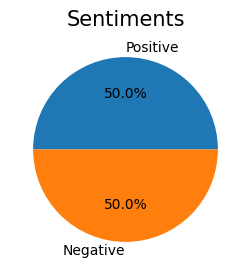

```python
labels = ['Positive', 'Negative']
plt.rcParams['figure.figsize'] = (3, 3)
plt.pie(df['Label'].value_counts(), labels = labels, autopct = "%.1f%%")
plt.axis('off')
plt.title('Sentiments', fontsize =15)
plt.show()
```

```python
df.describe().T
```

|  | count | mean | std | min | 25% | 50% | 75% | max |
| --- | --- | --- | --- | --- | --- | --- | --- | --- |
| Label | 25000.0 | 0.50000 | 0.500010 | 0.0 | 0.0 | 0.5 | 1.0 | 1.0 |
| review_length | 25000.0 | 238.71364 | 176.497204 | 11.0 | 130.0 | 178.0 | 291.0 | 2494.0 |

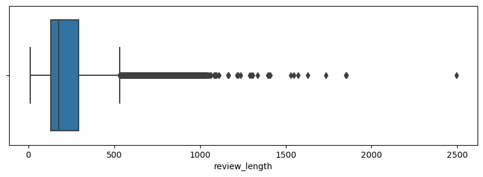

```python
# Plotting review length
plt.figure(figsize= (10,3))
sns.boxplot(x = df['review_length']);
```

Observations:

- There are 25000 reviews in train data and 25000 reviews in test data.
- The reviews are already preprocessed.
- The sentiments are in binary format and are distributed equally in the dataset as seen from graph.
- We can try merging both train and test data to form a bigger corpus and then use train-test-split to get more training data. This seems to be out of scope for now.

**2. Perform relevant sequence adding on the data.**

Based on the above info, the max value of review length is around 500 excluding the outliers. Hence, we will truncate the reviews to 500 to get a fixed length input. For shorter reviews, we will fill the unused word slots with zeros.

```python
from keras.utils import pad_sequences
max_review_length = 500

x_train = pad_sequences(x_train, padding='post', maxlen = max_review_length)

x_test = pad_sequences(x_test, padding='post', maxlen = max_review_length)
```

**3. Perform following data analysis:**

**• Print shape of features and labels**

```python
print ('X_train : Rows = ', x_train.shape[0], 'and Columns = ', x_train.shape[1])
print ('y_train : Rows = ', y_train.shape[0])
print ('X_test  : Rows = ', x_test.shape[0], 'and Columns = ', x_test.shape[1])
print ('y_test  : Rows = ', y_test.shape[0])
```

```
X_train : Rows =  25000 and Columns =  500
y_train : Rows =  25000
X_test  : Rows =  25000 and Columns =  500
y_test  : Rows =  25000
```

**• Print value of any one feature and it's label**

```python
print('Feature :' , x_train[10])
print('Label   :', y_train[10])
```

```
Feature : [   1  785  189  438   47  110  142    7    6 7475  120    4  236  378
    7  153   19   87  108  141   17 1004    5    2  883    2   23    8
    4  136    2    2    4 7475   43 1076   21 1407  419    5 5202  120
   91  682  189 2818    5    9 1348   31    7    4  118  785  189  108
  126   93    2   16  540  324   23    6  364  352   21   14    9   93
   56   18   11  230   53  771   74   31   34    4 2834    7    4   22
    5   14   11  471    9    2   34    4  321  487    5  116   15 6584
    4   22    9    6 2286    4  114 2679   23  107  293 1008 1172    5
  328 1236    4 1375  109    9    6  132  773    2 1412    8 1172   18
 7865   29    9  276   11    6 2768   19  289  409    4 5341 2140    2
  648 1430    2 8914    5   27 3000 1432 7130  103    6  346  137   11
    4 2768  295   36 7740  725    6 3208  273   11    4 1513   15 1367
   35  154    2  103    2  173    7   12   36  515 3547   94 2547 1722
    5 3547   36  203   30  502    8  361   12    8  989  143    4 1172
 3404   10   10  328 1236    9    6   55  221 2989    5  146  165  179
```

[output cut: 22 more lines]

**4. Decode the feature value to get original sentence**

The indices are offset by 3 because 0, 1 and 2 are reserved indices for "padding", "start of sequence" and "unknown".

```python
def decode_review(sequence):
  return " ".join( [reverse_index.get(i - 3, "#") for i in sequence])

index = imdb.get_word_index()
reverse_index = dict([(value, key) for (key, value) in index.items()])
df['Text_review'] = ''
df['Text_review'] = df['Review'].apply(decode_review)
```

```
Downloading data from https://storage.googleapis.com/tensorflow/tf-keras-datasets/imdb_word_index.json
```

```python
df
```

|  | Review | Label | review_length | Text_review |
| --- | --- | --- | --- | --- |
| 0 | [1, 14, 22, 16, 43, 530, 973, 1622, 1385, 65, ... | 1 | 218 | # this film was just brilliant casting locatio... |
| 1 | [1, 194, 1153, 194, 8255, 78, 228, 5, 6, 1463,... | 0 | 189 | # big hair big boobs bad music and a giant saf... |
| 2 | [1, 14, 47, 8, 30, 31, 7, 4, 249, 108, 7, 4, 5... | 0 | 141 | # this has to be one of the worst films of the... |
| 3 | [1, 4, 2, 2, 33, 2804, 4, 2040, 432, 111, 153,... | 1 | 550 | # the # # at storytelling the traditional sort... |
| 4 | [1, 249, 1323, 7, 61, 113, 10, 10, 13, 1637, 1... | 0 | 147 | # worst mistake of my life br br i picked this... |
| ... | ... | ... | ... | ... |
| 24995 | [1, 14, 9, 6, 2758, 20, 21, 1517, 7, 2078, 5, ... | 1 | 180 | # this is a racist movie but worthy of study a... |
| 24996 | [1, 4679, 2784, 299, 6, 1042, 37, 80, 81, 233,... | 0 | 328 | # bela lugosi plays a doctor who will do anyth... |
| 24997 | [1, 11, 6, 230, 245, 6401, 9, 6, 1225, 446, 2,... | 0 | 184 | # in a far away galaxy is a planet called # it... |
| 24998 | [1, 1446, 7079, 69, 72, 3305, 13, 610, 930, 8,... | 1 | 150 | # six degrees had me hooked i looked forward t... |
| 24999 | [1, 17, 6, 194, 337, 7, 4, 204, 22, 45, 254, 8... | 0 | 153 | # as a big fan of the original film it's hard ... |

25000 rows × 4 columns

**5. Design, train, tune and test a sequential model.**

```python
# Capturing learning history per epoch
def print_report(history, model):

  loss, accuracy = model.evaluate(x_test, y_test, verbose = False)

  hist  = pd.DataFrame(history.history)
  hist['epoch'] = history.epoch

  # Plotting loss at different epochs
  plt.plot(hist['loss'])
  plt.plot(hist['val_loss'])
  plt.legend(("training","validation"), loc = 'best')
  plt.title('model loss')
  plt.xlabel("Number of Epochs")
  plt.ylabel("Learning Loss")
  plt.show()

  print('--------------------------------------')

  # Plotting accuracy at different epochs
  plt.plot(hist['accuracy'])
  plt.plot(hist['val_accuracy'])
  plt.title('model accuracy')
  plt.ylabel('Accuracy')
  plt.xlabel('Number of Epochs')
  plt.legend(['training', 'validation'], loc='best')
  plt.show()

  # predicting the class on test data
  y_pred = model.predict(x_test)
  y_pred = np.round(y_pred).astype(int)

  # Classification Report
  print('\n\nClassification Report')
  print('--------------------------------------')
  print(classification_report(y_test, y_pred))

  # Confusion Matrix
  print('\n\nConfusion Matrix')
  print('--------------------------------------')
  cm=confusion_matrix(y_test, y_pred)
  plt.figure(figsize=(3,3))
  sns.heatmap(cm,annot=True,fmt='d')
  plt.xlabel('Predicted')
  plt.ylabel('Truth')
  plt.show()
```

```
Model: "sequential"
_________________________________________________________________
 Layer (type)                Output Shape              Param #
=================================================================
 embedding (Embedding)       (None, 500, 256)          2560000

 dense (Dense)               (None, 500, 250)          64250

 dropout (Dropout)           (None, 500, 250)          0

 flatten (Flatten)           (None, 125000)            0

 dense_1 (Dense)             (None, 150)               18750150

 dropout_1 (Dropout)         (None, 150)               0

 dense_2 (Dense)             (None, 1)                 151

=================================================================
Total params: 21,374,551
Trainable params: 21,374,551
Non-trainable params: 0
_________________________________________________________________
```

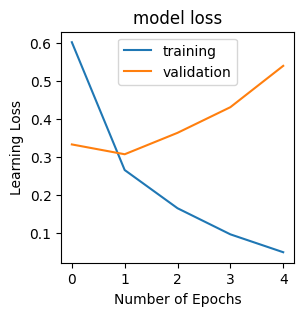

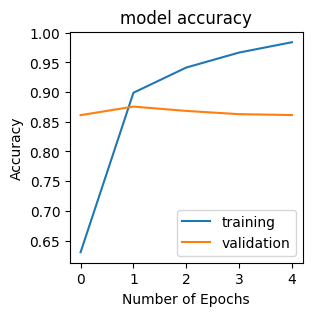

```
Classification Report
--------------------------------------
              precision    recall  f1-score   support

           0       0.85      0.88      0.86     12500
           1       0.88      0.84      0.86     12500

    accuracy                           0.86     25000
   macro avg       0.86      0.86      0.86     25000
weighted avg       0.86      0.86      0.86     25000



Confusion Matrix
--------------------------------------
```

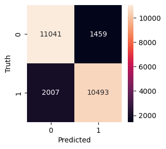

```python
# Model 1 -  base NN model with couple of layers
model1 = Sequential()

# Input Layer
model1.add(Embedding(10000, 256, input_length = max_review_length))
model1.add(Dense(250, activation='relu'))
model1.add(Dropout(0.3, noise_shape=None, seed=None))
model1.add(Flatten())
model1.add(Dense(150, activation='relu'))
model1.add(Dropout(0.2, noise_shape=None, seed=None))

# Output Layer
model1.add(Dense(1, activation='sigmoid'))

# Compling Model
adam_opt = keras.optimizers.Adam(learning_rate = 0.001)
model1.compile(loss='binary_crossentropy', optimizer= adam_opt, metrics=['accuracy'])

# Model Summary
model1.summary()

# Adding callbacks
es = EarlyStopping(monitor='val_loss', verbose=1, mode='min', patience=100)
model_1 = model1.fit(x_train, y_train, validation_data=(x_test, y_test), epochs = 5, batch_size=128, callbacks=[es], verbose=0)

print_report(model_1, model1)
```

```
Model: "sequential_1"
_________________________________________________________________
 Layer (type)                Output Shape              Param #
=================================================================
 embedding_1 (Embedding)     (None, 500, 256)          2560000

 dropout_2 (Dropout)         (None, 500, 256)          0

 conv1d (Conv1D)             (None, 500, 256)          327936

 conv1d_1 (Conv1D)           (None, 500, 128)          163968

 max_pooling1d (MaxPooling1D  (None, 250, 128)         0
 )

 conv1d_2 (Conv1D)           (None, 250, 64)           41024

 max_pooling1d_1 (MaxPooling  (None, 125, 64)          0
 1D)

 lstm (LSTM)                 (None, 75)                42000

 dense_3 (Dense)             (None, 1)                 76

=================================================================
Total params: 3,135,004
Trainable params: 3,135,004
Non-trainable params: 0
_________________________________________________________________
None
```

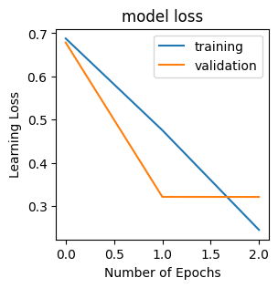

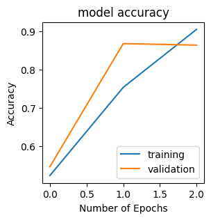

```
Classification Report
--------------------------------------
              precision    recall  f1-score   support

           0       0.82      0.94      0.87     12500
           1       0.93      0.79      0.85     12500

    accuracy                           0.86     25000
   macro avg       0.87      0.86      0.86     25000
weighted avg       0.87      0.86      0.86     25000



Confusion Matrix
--------------------------------------
```

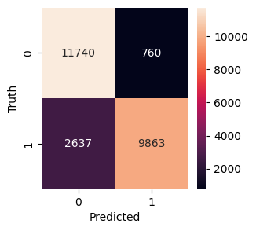

```python
# Model 2 using couple of Convolution layers, MaxPool and LSTM
model2 = Sequential()
model2.add(Embedding(10000, 256, input_length = max_review_length))
model2.add(Dropout(0.25))
model2.add(Conv1D(256, 5, padding = 'same', activation = 'relu', strides = 1))
model2.add(Conv1D(128, 5, padding = 'same', activation = 'relu', strides = 1))
model2.add(MaxPooling1D(pool_size = 2))
model2.add(Conv1D(64, 5, padding = 'same', activation = 'relu', strides = 1))
model2.add(MaxPooling1D(pool_size = 2))
model2.add(LSTM(75))
model2.add(Dense(1, activation = 'sigmoid'))
model2.compile(loss = 'binary_crossentropy', optimizer = 'adam', metrics = ['accuracy'])
print(model2.summary())

# Adding callbacks
es = EarlyStopping(monitor = 'val_loss', mode = 'min', verbose = 1, patience = 0)

# Fit the model
model_2 = model2.fit(x_train, y_train, validation_data = (x_test, y_test), epochs = 3, batch_size = 64, verbose = True, callbacks = es)

print_report(model_2, model2)
```

```
Model: "sequential_2"
_________________________________________________________________
 Layer (type)                Output Shape              Param #
=================================================================
 embedding_2 (Embedding)     (None, 500, 32)           320000

 conv1d_3 (Conv1D)           (None, 500, 32)           3104

 max_pooling1d_2 (MaxPooling  (None, 250, 32)          0
 1D)

 flatten_1 (Flatten)         (None, 8000)              0

 dense_4 (Dense)             (None, 250)               2000250

 dense_5 (Dense)             (None, 1)                 251

=================================================================
Total params: 2,323,605
Trainable params: 2,323,605
Non-trainable params: 0
_________________________________________________________________
Epoch 2: early stopping
```

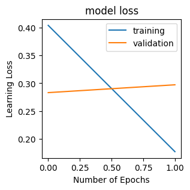

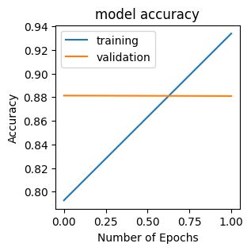

```
Classification Report
--------------------------------------
              precision    recall  f1-score   support

           0       0.87      0.89      0.88     12500
           1       0.89      0.87      0.88     12500

    accuracy                           0.88     25000
   macro avg       0.88      0.88      0.88     25000
weighted avg       0.88      0.88      0.88     25000



Confusion Matrix
--------------------------------------
```

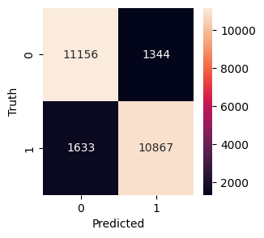

```python
# Model 3 - Simple Convolution layer to base NN model
model3 = Sequential()
model3.add(Embedding(10000, 32, input_length=max_review_length))
model3.add(Conv1D(filters=32, kernel_size=3, padding='same', activation='relu'))
model3.add(MaxPooling1D(pool_size=2))
model3.add(Flatten())
model3.add(Dense(250, activation='relu'))
model3.add(Dense(1, activation='sigmoid'))
model3.compile(loss='binary_crossentropy', optimizer='adam', metrics=['accuracy'])
model3.summary()

# Adding callbacks
es = EarlyStopping(monitor = 'val_loss', mode = 'min', verbose = 1, patience = 0)

# Fit the model
model_3 = model3.fit(x_train, y_train, validation_data = (x_test, y_test), epochs = 3, batch_size = 64, verbose = True, callbacks = es)

print_report(model_3, model3)
```

Observations:

From the above 3 models, model3 seems to have better accuracy compared to others.

Model 3 - a convolutional neural network model takes Embedding layer as the input layer with vocabulary 10000, the word vector size as 32 dimensions, and the input_length to 500. The output of this first layer will be a 32×500-sized matrix. The convolutional layer has 32 feature maps and reads embedded word representations’ three vector elements of the word embedding at a time. It is followed by a 1D max pooling layer with a length and stride of 2 that halves the size of the feature maps from the convolutional layer. Flatten the previous output to one dimension, dense hidden layer of 250 units with a rectifier activation function. The output layer has one neuron and will use a sigmoid activation to output values of 0 and 1 as predictions. The model uses logarithmic loss and is optimized using the efficient ADAM optimization procedure.

Performance:

1. About 1600 labels are wrongly classified as 0.
2. About 1300 labels are wrongly classified as 1.
3. Accuracy and F1 score are at 88%.

Hence we will go with the model 3 as our final model for further evaluation.

**6. Use the designed model to print the prediction on any one sample.**

```python
y_pred = model3.predict(x_test)
y_pred = np.round(y_pred).astype(int)
```

```python
for i in range(10):
  print('Review Index %d :' %i, 'Actual Sentiment %d - ' % y_test[i] , 'Predicted Sentiment %d\n'%y_pred[i][0])
```

```
Review Index 0 : Actual Sentiment 0 -  Predicted Sentiment 0

Review Index 1 : Actual Sentiment 1 -  Predicted Sentiment 1

Review Index 2 : Actual Sentiment 1 -  Predicted Sentiment 1

Review Index 3 : Actual Sentiment 0 -  Predicted Sentiment 0

Review Index 4 : Actual Sentiment 1 -  Predicted Sentiment 1

Review Index 5 : Actual Sentiment 1 -  Predicted Sentiment 1

Review Index 6 : Actual Sentiment 1 -  Predicted Sentiment 1

Review Index 7 : Actual Sentiment 0 -  Predicted Sentiment 0

Review Index 8 : Actual Sentiment 0 -  Predicted Sentiment 1

Review Index 9 : Actual Sentiment 1 -  Predicted Sentiment 1
```

**Observation:**:

The model is able to predict better as seen from above results with Accuracy and F1 Score 88%. This is a slight improvement of around 2% compared to other models.

## **PART B**

• DOMAIN: Social media analytics

• CONTEXT: Past studies in Sarcasm Detection mostly make use of Twitter datasets collected using hashtag based supervision but such datasets are noisy in terms of labels and language. Furthermore, many tweets are replies to other tweets and detecting sarcasm in these requires the availability of contextual tweets.In this hands-on project, the goal is to build a model to detect whether a sentence is sarcastic or not, using Bidirectional LSTMs.

• DATA DESCRIPTION: The dataset is collected from two news websites, theonion.com and huffingtonpost.com. This new dataset has the following advantages over the existing Twitter datasets:Since news headlines are written by professionals in a formal manner, there are no spelling mistakes and informal usage. This reduces the sparsity and also increases the chance of finding pre-trained embeddings.Furthermore, since the sole purpose of TheOnion is to publish sarcastic news, we get high-quality labels with much less noise as compared to Twitter datasets.Unlike tweets that reply to other tweets, the news headlines obtained are self-contained. This would help us in teasing apart the real sarcastic elements

• Content: Each record consists of three attributes:

- is_sarcastic: 1 if the record is sarcastic otherwise 0
- headline: the headline of the news article
- article_link: link to the original news article. Useful in collecting supplementary data  
  Reference: https://github.com/rishabhmisra/News-Headlines-Dataset-For-Sarcasm-Detection

• PROJECT OBJECTIVE: Build a sequential NLP classifier which can use input text parameters to determine the customer sentiments

**1. Read and explore the data**

```python
#Importing all the necessary libraries
import os
import string
import regex as re
import numpy as np
import pandas as pd
import matplotlib.pyplot as plt
%matplotlib inline
import seaborn as sns
import warnings
warnings.filterwarnings("ignore") # To ignore any warnings

from sklearn.model_selection import train_test_split
from sklearn.metrics import accuracy_score, confusion_matrix, classification_report # Performance Metrics

from wordcloud import WordCloud # To display WordCloud

# Tensorflow Library
import tensorflow as tf
```

```python
from google.colab import drive
drive.mount('/content/drive')
```

```python
project_path = r"/content/drive/MyDrive/Colab Notebooks/"
os.chdir(project_path)
```

```python
data_source = 'https://raw.githubusercontent.com/rishabhmisra/News-Headlines-Dataset-For-Sarcasm-Detection/master/Sarcasm_Headlines_Dataset.json'

data = pd.read_json(data_source, lines=True)
data.sample(5)
```

|  | is_sarcastic | headline | article_link |
| --- | --- | --- | --- |
| 3739 | 0 | controversial photo-editing app under fire for... | https://www.huffingtonpost.com/entry/makeapp-m... |
| 11707 | 0 | sorry gop, mike pence can't save you from dona... | https://www.huffingtonpost.com/entry/mike-penc... |
| 1611 | 0 | innocent man awarded $1 million after spending... | https://www.huffingtonpost.com/entry/man-award... |
| 27821 | 1 | trump retweets video from anti-muslim hate group | https://politics.theonion.com/trump-retweets-v... |
| 8076 | 0 | peyton manning goes to graduation, starts thro... | https://www.huffingtonpost.com/entry/peyton-ma... |

```python
data.info()
```

```
<class 'pandas.core.frame.DataFrame'>
RangeIndex: 28619 entries, 0 to 28618
Data columns (total 3 columns):
 #   Column        Non-Null Count  Dtype
---  ------        --------------  -----
 0   is_sarcastic  28619 non-null  int64
 1   headline      28619 non-null  object
 2   article_link  28619 non-null  object
dtypes: int64(1), object(2)
memory usage: 670.9+ KB
```

```python
data.shape
```

```
(28619, 3)
```

**Observations:** The dataset contains 28619 articles. It has three columns - 'is_sarcastic (int data type), headline (Object data type), article_link(Object data type)'.

```python
data.isnull().sum()
```

```
is_sarcastic    0
headline        0
article_link    0
dtype: int64
```

**Observations:** NO null values in the dataset

```python
data['is_sarcastic'].value_counts()
```

```
0    14985
1    13634
Name: is_sarcastic, dtype: int64
```

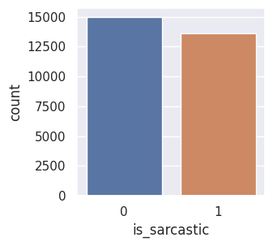

```python
plt.figure(figsize=(3,3))
sns.set(style="darkgrid")
sns.countplot(x = data['is_sarcastic']);
```

**Observations:** Sarcastic data is slightly less compared to other label but overall the dataset is balanced.

```python
# Retrieve source from the article_link and analyse the count
data['source'] = data['article_link'].apply(lambda x: re.findall(r'\w+', x)[2])
data.head()
```

|  | is_sarcastic | headline | article_link | source |
| --- | --- | --- | --- | --- |
| 0 | 1 | thirtysomething scientists unveil doomsday clo... | https://www.theonion.com/thirtysomething-scien... | theonion |
| 1 | 0 | dem rep. totally nails why congress is falling... | https://www.huffingtonpost.com/entry/donna-edw... | huffingtonpost |
| 2 | 0 | eat your veggies: 9 deliciously different recipes | https://www.huffingtonpost.com/entry/eat-your-... | huffingtonpost |
| 3 | 1 | inclement weather prevents liar from getting t... | https://local.theonion.com/inclement-weather-p... | theonion |
| 4 | 1 | mother comes pretty close to using word 'strea... | https://www.theonion.com/mother-comes-pretty-c... | theonion |

```python
data['source'].value_counts()
```

```
huffingtonpost    14985
theonion          13634
Name: source, dtype: int64
```

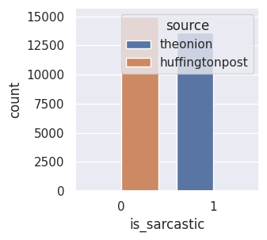

```python
plt.figure(figsize=(3,3))
sns.set(style="darkgrid")
sns.countplot(x = data['is_sarcastic'], hue = data['source']);
```

**Observations:** All articles of huffingtonpost are not sarcastic but articles from theonion are all sarcastic.

**2. Retain relevant columns**

```python
data.head()
```

|  | is_sarcastic | headline | article_link | source |
| --- | --- | --- | --- | --- |
| 0 | 1 | thirtysomething scientists unveil doomsday clo... | https://www.theonion.com/thirtysomething-scien... | theonion |
| 1 | 0 | dem rep. totally nails why congress is falling... | https://www.huffingtonpost.com/entry/donna-edw... | huffingtonpost |
| 2 | 0 | eat your veggies: 9 deliciously different recipes | https://www.huffingtonpost.com/entry/eat-your-... | huffingtonpost |
| 3 | 1 | inclement weather prevents liar from getting t... | https://local.theonion.com/inclement-weather-p... | theonion |
| 4 | 1 | mother comes pretty close to using word 'strea... | https://www.theonion.com/mother-comes-pretty-c... | theonion |

```python
# Drop article_link and source from dataset as they are no more needed.
data.drop(['article_link', 'source'], axis = 1, inplace = True)
data.head()
```

|  | is_sarcastic | headline |
| --- | --- | --- |
| 0 | 1 | thirtysomething scientists unveil doomsday clo... |
| 1 | 0 | dem rep. totally nails why congress is falling... |
| 2 | 0 | eat your veggies: 9 deliciously different recipes |
| 3 | 1 | inclement weather prevents liar from getting t... |
| 4 | 1 | mother comes pretty close to using word 'strea... |

**3. Get length of each sentence**

```python
# Capturing each sentence lengths
data['sentences_lengths'] = data['headline'].apply(lambda x: len(x))
data.head()
```

|  | is_sarcastic | headline | sentences_lengths |
| --- | --- | --- | --- |
| 0 | 1 | thirtysomething scientists unveil doomsday clo... | 61 |
| 1 | 0 | dem rep. totally nails why congress is falling... | 79 |
| 2 | 0 | eat your veggies: 9 deliciously different recipes | 49 |
| 3 | 1 | inclement weather prevents liar from getting t... | 52 |
| 4 | 1 | mother comes pretty close to using word 'strea... | 61 |

```python
data.describe().T
```

|  | count | mean | std | min | 25% | 50% | 75% | max |
| --- | --- | --- | --- | --- | --- | --- | --- | --- |
| is_sarcastic | 28619.0 | 0.476397 | 0.499451 | 0.0 | 0.0 | 0.0 | 1.0 | 1.0 |
| sentences_lengths | 28619.0 | 62.308571 | 20.726483 | 7.0 | 49.0 | 62.0 | 75.0 | 926.0 |

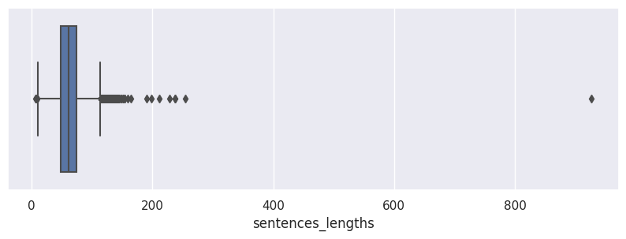

```python
# Plotting review length
plt.figure(figsize= (10,3))
sns.boxplot(x = data['sentences_lengths']);
```

```python
data.sort_values(by=['sentences_lengths'], ascending=False)
```

|  | is_sarcastic | headline | sentences_lengths |
| --- | --- | --- | --- |
| 7302 | 1 | hot wheels ranked number one toy for rolling d... | 926 |
| 2146 | 1 | maya angelou, poet, author, civil rights activ... | 254 |
| 16588 | 1 | '12 years a slave,' 'captain phillips,' 'ameri... | 238 |
| 24815 | 1 | elmore leonard, modern prose master, noted for... | 237 |
| 23598 | 0 | occasionally you realize someone you thought w... | 228 |
| ... | ... | ... | ... |
| 13216 | 1 | dip good | 8 |
| 17383 | 1 | ant born | 8 |
| 11889 | 0 | déjà vu? | 8 |
| 10120 | 1 | top cute | 8 |
| 28376 | 0 | bye bye | 7 |

28619 rows × 3 columns

```
[Text(0.5, 0, 'Sentence Lengths')]
```

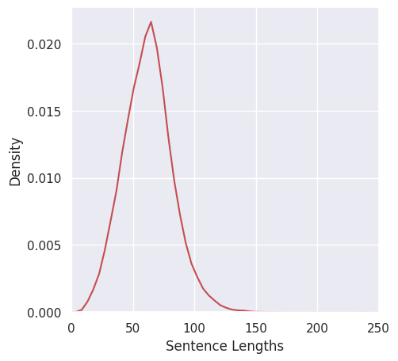

```python
# PLotting sentence length distribution
plt.figure(figsize=(5,5))
plt.xlim(0, 250)
ax = sns.distplot(data['sentences_lengths'], hist=False, color="r")
ax.set(xlabel='Sentence Lengths')
```

**Observations:**

**4. Define parameters**

```python
# Hyperparameters
vocab_size = 30000
oov_token = '<00V>'
max_length = 125
padding_type = 'post'
trunc_type = 'post'
embedding_dim = 50
batch_size = 256
num_epochs = 10
```

**5. Get indices for words**

```python
tokenizer = tf.keras.preprocessing.text.Tokenizer(num_words=vocab_size, oov_token=oov_token)
tokenizer.fit_on_texts(data['headline'])
```

```python
word_index = tokenizer.word_index
```

```python
word_index
```

[output not shown]

[output cut: 946 more lines]

```
 'culture': 987,
 'magazine': 988,
 'throws': 989,
 'leads': 990,
 'eyes': 991,
 'humans': 992,
 'chicken': 993,
 'beauty': 994,
 'crime': 995,
 'recalls': 996,
 'energy': 997,
 'voting': 998,
 'question': 999,
 'episode': 1000,
 ...}
```

**6. Create features and labels**

```python
X = tokenizer.texts_to_sequences(data['headline'])
X = tf.keras.preprocessing.sequence.pad_sequences(X, maxlen=max_length, padding=padding_type, truncating=trunc_type)
y = np.asarray(data['is_sarcastic'])

print("Number of Samples:", len(X))
print(X[0])
print("\nNumber of Labels:", len(y))
print(y[0])
```

```
Number of Samples: 28619
[16004   355  3167  7474  2644     3   661  1119     0     0     0     0
     0     0     0     0     0     0     0     0     0     0     0     0
     0     0     0     0     0     0     0     0     0     0     0     0
     0     0     0     0     0     0     0     0     0     0     0     0
     0     0     0     0     0     0     0     0     0     0     0     0
     0     0     0     0     0     0     0     0     0     0     0     0
     0     0     0     0     0     0     0     0     0     0     0     0
     0     0     0     0     0     0     0     0     0     0     0     0
     0     0     0     0     0     0     0     0     0     0     0     0
     0     0     0     0     0     0     0     0     0     0     0     0
     0     0     0     0     0]

Number of Labels: 28619
1
```

**7. Get vocabulary size**

```python
# Vocabulary Size
num_words = len(tokenizer.word_index) + 1
print(" Total no. of words in tokenizer: ", num_words)
```

```
 Total no. of words in tokenizer:  30886
```

**8. Create a weight matrix using GloVe embeddings**

```python
embeddings = {}
for g in open('glove.6B.50d.txt'):
  word = g.split(" ")[0]
  embd = g.split(" ")[1:]
  embd = np.asarray(embd, dtype=np.float32)
  embeddings[word] = embd
```

```python
print("Length of embeddings: ", len(embeddings.values()))
```

```
Length of embeddings:  400000
```

```python
embedding_matrix = np.zeros((num_words, embedding_dim))

for word, i in tokenizer.word_index.items():
    embedding_vector = embeddings.get(word)
    if embedding_vector is not None:
        embedding_matrix[i] = embedding_vector

len(embeddings.values())
```

```
400000
```

```python
print("Shape of embedding matrix : ", embedding_matrix.shape)
```

```
Shape of embedding matrix :  (30886, 50)
```

```python
print("Embedding Matrix sample: ")
embedding_matrix[10]
```

```
Embedding Matrix sample:
```

```
array([ 0.25615999,  0.43694001, -0.11889   ,  0.20344999,  0.41959   ,
        0.85863   , -0.60343999, -0.31834999, -0.67180002,  0.003984  ,
       -0.075159  ,  0.11043   , -0.73534   ,  0.27436   ,  0.054015  ,
       -0.23828   , -0.13767   ,  0.011573  , -0.46623001, -0.55233002,
        0.083317  ,  0.55937999,  0.51902997, -0.27065   , -0.28211001,
       -1.39180005,  0.17498   ,  0.26585999,  0.061449  , -0.273     ,
        3.90319991,  0.38169   , -0.056009  , -0.004425  ,  0.24033   ,
        0.30675   , -0.12638   ,  0.33436   ,  0.075485  , -0.036218  ,
        0.13691001,  0.37762001, -0.12159   , -0.13808   ,  0.19505   ,
        0.22792999, -0.17304   , -0.07573   , -0.25867999, -0.39339   ])
```

**9. Define and compile a Bidirectional LSTM model.**

**10. Fit the model and check the validation accuracy**

```python
y = y.reshape(-1,1)
```

```python
# Train - Test Split
X_train, X_test, y_train, y_test = train_test_split(X, y, shuffle = True, random_state = 10, test_size = 0.3, stratify = y)
```

```python
print("Shape of Training Data: ", X_train.shape)
print('-' * 30)
print("Shape of Testing Data: ", X_test.shape)
```

```
Shape of Training Data:  (20033, 125)
------------------------------
Shape of Testing Data:  (8586, 125)
```

```python
tf.keras.backend.clear_session() # Clear previous session
base1 = tf.keras.models.Sequential() # Model instantiation
base1.add(tf.keras.layers.Embedding(num_words, embedding_dim, weights = [embedding_matrix], input_length=max_length)) #Input Layer
base1.add(tf.keras.layers.Bidirectional(tf.keras.layers.LSTM(64, return_sequences=True))) # Bidirectional LSTM Layer
base1.add(tf.keras.layers.GlobalAveragePooling1D())
base1.add(tf.keras.layers.Dense(32, activation='relu'))
base1.add(tf.keras.layers.Dense(1, activation='sigmoid')) # Output Layer

# Compiling the model
base1.compile(loss='binary_crossentropy',optimizer='adam', metrics=['accuracy'])
# Model Summary
base1.summary()
```

```
Model: "sequential"
_________________________________________________________________
 Layer (type)                Output Shape              Param #
=================================================================
 embedding (Embedding)       (None, 125, 50)           1544300

 bidirectional (Bidirectiona  (None, 125, 128)         58880
 l)

 global_average_pooling1d (G  (None, 128)              0
 lobalAveragePooling1D)

 dense (Dense)               (None, 32)                4128

 dense_1 (Dense)             (None, 1)                 33

=================================================================
Total params: 1,607,341
Trainable params: 1,607,341
Non-trainable params: 0
_________________________________________________________________
```

```python
mc = tf.keras.callbacks.ModelCheckpoint('base_model_best.hdf5', monitor='val_accuracy', verbose=1, save_best_only=True, mode='max')
es = tf.keras.callbacks.EarlyStopping(monitor="val_accuracy", mode="max", patience=5)
base_history1 = base1.fit(X_train, y_train, batch_size = batch_size, epochs = num_epochs, callbacks=[mc, es], validation_data=(X_test, y_test), verbose=1)
```

```
Epoch 1: val_accuracy improved from -inf to 0.70953, saving model to base_model_best.hdf5
Epoch 2: val_accuracy improved from 0.70953 to 0.75087, saving model to base_model_best.hdf5
Epoch 3: val_accuracy improved from 0.75087 to 0.80620, saving model to base_model_best.hdf5
Epoch 4: val_accuracy improved from 0.80620 to 0.83566, saving model to base_model_best.hdf5
Epoch 5: val_accuracy improved from 0.83566 to 0.83776, saving model to base_model_best.hdf5
Epoch 6: val_accuracy did not improve from 0.83776
Epoch 7: val_accuracy did not improve from 0.83776
Epoch 8: val_accuracy did not improve from 0.83776
Epoch 9: val_accuracy did not improve from 0.83776
Epoch 10: val_accuracy did not improve from 0.83776
```

```python
# Capturing learning history per epoch
def print_report(history, model):

  loss, accuracy = model.evaluate(X_test, y_test, verbose = False)

  hist  = pd.DataFrame(history.history)
  hist['epoch'] = history.epoch

  # Plotting loss at different epochs
  plt.plot(hist['loss'])
  plt.plot(hist['val_loss'])
  plt.legend(("training","validation"), loc = 'best')
  plt.title('model loss')
  plt.xlabel("Number of Epochs")
  plt.ylabel("Learning Loss")
  plt.show()

  print('--------------------------------------')

  # Plotting accuracy at different epochs
  plt.plot(hist['accuracy'])
  plt.plot(hist['val_accuracy'])
  plt.title('model accuracy')
  plt.ylabel('Accuracy')
  plt.xlabel('Number of Epochs')
  plt.legend(['training', 'validation'], loc='best')
  plt.show()

  # Predicting for all of test dataset
  model_predictions = model.predict(X_test, batch_size=1024).round().astype(int)
  model_predictions[0]

  # Inversing probability into test labels
  model_predictions = [np.round(x[0]) for x in model_predictions]

  # Classification Report
  print('\n\nClassification Report')
  print('--------------------------------------')
  print(classification_report(y_test, model_predictions, target_names = ['Unsarcastic','Sarcastic']))

  # Confusion Matrix

  cm = confusion_matrix(y_test,model_predictions)
  plt.figure(figsize=(8,8))
  sns.heatmap(cm, annot = True, fmt = '.3f', linewidths = .5, square = True, cmap="YlGnBu")
  plt.ylabel('Actual Label')
  plt.xlabel('Predicted Label')
```

```python
best_model1 = tf.keras.models.load_model('base_model_best.hdf5')
```

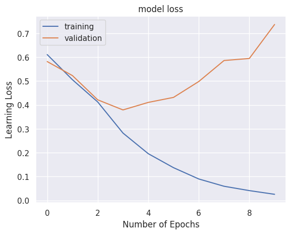

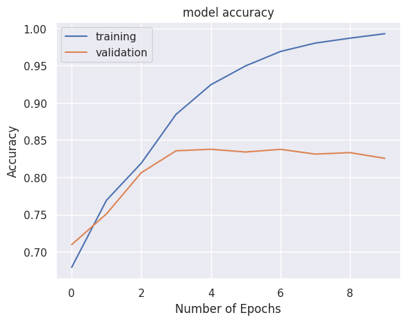

```
Classification Report
--------------------------------------
              precision    recall  f1-score   support

 Unsarcastic       0.89      0.79      0.84      4496
   Sarcastic       0.79      0.89      0.84      4090

    accuracy                           0.84      8586
   macro avg       0.84      0.84      0.84      8586
weighted avg       0.84      0.84      0.84      8586
```

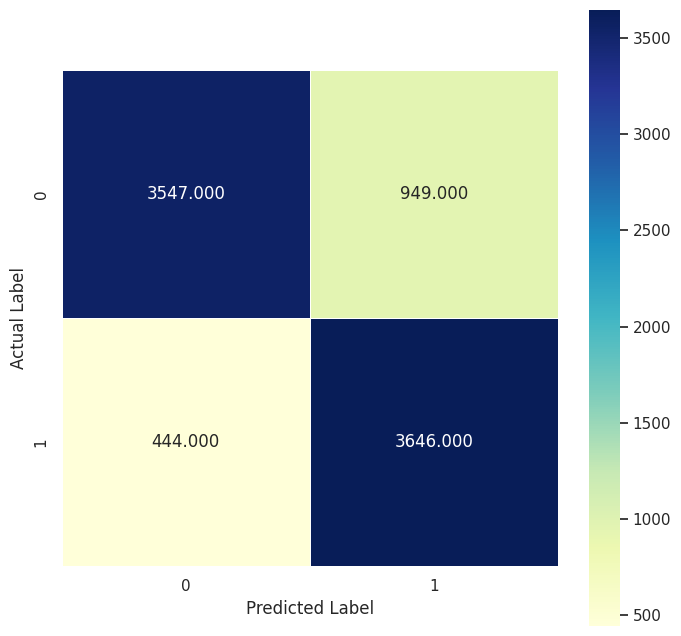

```python
print_report(base_history1, best_model1)
```

**Observations:**

1. Accuracy of 84% is acheived with base model1.
2. 444 articles are wrongly classified as Not Sarcastic
3. 949 articles are wrongly classified as sarcastic.
4. This model seems to be overfitting.

```python
# Base Model 2 Architechture with more dense layers and different learning rate
tf.keras.backend.clear_session() # Clear previous session
base2 = tf.keras.models.Sequential() # Model instantiation
base2.add(tf.keras.layers.Embedding(num_words, embedding_dim, weights = [embedding_matrix], input_length=max_length))
base2.add(tf.keras.layers.Bidirectional(tf.keras.layers.LSTM(128, return_sequences=True)))
base2.add(tf.keras.layers.GlobalAveragePooling1D())
base2.add(tf.keras.layers.Dense(64, activation='relu', kernel_initializer='he_normal', kernel_regularizer=tf.keras.regularizers.L2(l=0.01)))
base2.add(tf.keras.layers.Dropout(0.4))
base2.add(tf.keras.layers.Dense(32, activation='relu', kernel_initializer='he_normal', kernel_regularizer=tf.keras.regularizers.L2(l=0.01)))
base2.add(tf.keras.layers.Dropout(0.4))
base2.add(tf.keras.layers.Dense(16, activation='relu', kernel_initializer='he_normal', kernel_regularizer=tf.keras.regularizers.L2(l=0.01)))
base2.add(tf.keras.layers.Dropout(0.4))
base2.add(tf.keras.layers.Dense(1, activation='sigmoid'))
# Compiling the model
adam_opt = tf.keras.optimizers.Adam(learning_rate=0.0001)
base2.compile(loss='binary_crossentropy',optimizer=adam_opt, metrics=['accuracy'])
# Model Summary
base2.summary()
```

```
Model: "sequential"
_________________________________________________________________
 Layer (type)                Output Shape              Param #
=================================================================
 embedding (Embedding)       (None, 125, 50)           1544300

 bidirectional (Bidirectiona  (None, 125, 256)         183296
 l)

 global_average_pooling1d (G  (None, 256)              0
 lobalAveragePooling1D)

 dense (Dense)               (None, 64)                16448

 dropout (Dropout)           (None, 64)                0

 dense_1 (Dense)             (None, 32)                2080

 dropout_1 (Dropout)         (None, 32)                0

 dense_2 (Dense)             (None, 16)                528

 dropout_2 (Dropout)         (None, 16)                0

 dense_3 (Dense)             (None, 1)                 17

=================================================================
Total params: 1,746,669
Trainable params: 1,746,669
Non-trainable params: 0
_________________________________________________________________
```

```python
mc = tf.keras.callbacks.ModelCheckpoint('model_best.hdf5', monitor='val_accuracy', verbose=1, save_best_only=True, mode='max')
es = tf.keras.callbacks.EarlyStopping(monitor="val_accuracy", mode="max", patience=5)
history2 = base2.fit(X_train, y_train, batch_size = batch_size, epochs = num_epochs, callbacks=[mc, es], validation_data=(X_test, y_test), verbose=1)
```

```
Epoch 1: val_accuracy improved from -inf to 0.61216, saving model to model_best.hdf5
Epoch 2: val_accuracy improved from 0.61216 to 0.70487, saving model to model_best.hdf5
Epoch 3: val_accuracy improved from 0.70487 to 0.74086, saving model to model_best.hdf5
Epoch 4: val_accuracy improved from 0.74086 to 0.76811, saving model to model_best.hdf5
Epoch 5: val_accuracy improved from 0.76811 to 0.79595, saving model to model_best.hdf5
Epoch 6: val_accuracy improved from 0.79595 to 0.81505, saving model to model_best.hdf5
Epoch 7: val_accuracy improved from 0.81505 to 0.83182, saving model to model_best.hdf5
Epoch 8: val_accuracy improved from 0.83182 to 0.84451, saving model to model_best.hdf5
Epoch 9: val_accuracy improved from 0.84451 to 0.85243, saving model to model_best.hdf5
Epoch 10: val_accuracy improved from 0.85243 to 0.85476, saving model to model_best.hdf5
```

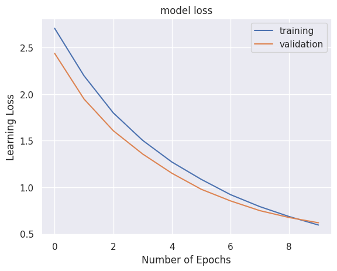

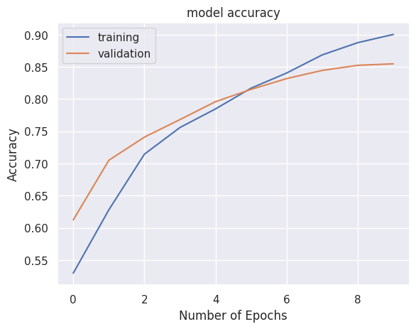

```
Classification Report
--------------------------------------
              precision    recall  f1-score   support

 Unsarcastic       0.88      0.84      0.86      4496
   Sarcastic       0.83      0.87      0.85      4090

    accuracy                           0.85      8586
   macro avg       0.85      0.86      0.85      8586
weighted avg       0.86      0.85      0.85      8586
```

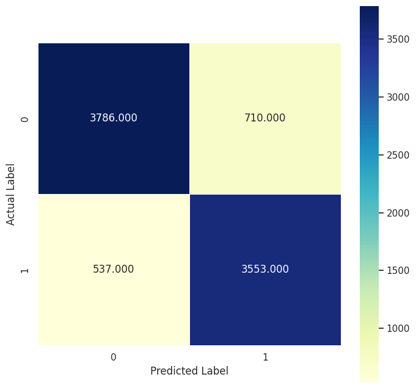

```python
best_model2 = tf.keras.models.load_model('model_best.hdf5')
print_report(history2, best_model2)
```

**Observations:**

1. Accuracy of 85% is acheived with model2.
2. 537 articles are wrongly classified as Not Sarcastic
3. 710 articles are wrongly classified as sarcastic.
4. Model 2 seems to be clearly less overfitting compared to model1.
5. Both training and validation data have similar loss and accuracy curves and good learning rate.
6. The difference between precision and recall for both labels also have significantly reduced in the second model.

Overall, Model 2 seems to be performing better and hence will use this model as our final model.